# Lab7_All_Regions

Rachael Cooper

10/20/2021

/——————–

*General Procedure*

1. Load data and necessary packages
2. Read in each article (total of 10-12), clean the data and do individual sentiment analysis and produce word clouds
3. Merge the article data together and do sentiment analysis of the entirety of the Chicago Daily Herald
4. Conduct TF-IDF analysis
5. Produce and analyze a sentiment range graph
6. Produce and analyze a word cloud, highlighting the top 50 represented words

/——————–

### Climate Change by Region Analysis

#### Northeast : NY Times

```r
NE[order(NE$tf_idf, decreasing = T, na.last = F),]
```

```
## # A tibble: 7,609 × 7
##    article    word          n total      tf   idf tf_idf
##    <chr>      <chr>     <dbl> <dbl>   <dbl> <dbl>  <dbl>
##  1 Article 9  prize        22  1656 0.0133   2.48 0.0330
##  2 Article 8  city         18   800 0.0225   1.39 0.0312
##  3 Article 10 capital       7   731 0.00958  2.48 0.0238
##  4 Article 10 private       9   731 0.0123   1.79 0.0221
##  5 Article 3  virginia     15  1808 0.00830  2.48 0.0206
##  6 Article 10 investors     6   731 0.00821  2.48 0.0204
##  7 Article 3  west         20  1808 0.0111   1.79 0.0198
##  8 Article 9  nobel        13  1656 0.00785  2.48 0.0195
##  9 Article 2  biden's      12  1589 0.00755  2.48 0.0188
## 10 Article 9  dr           26  1656 0.0157   1.10 0.0172
## # … with 7,599 more rows
```

The highest tf-idf value is found to be in article 9 and the word prize. This correlates with the positive sentiment values found above in the Northeast. The word “prize” may be associated with new and novel ideas, technology, and legislation to combat the growing problem of climate change. This demonstrates that the Northeast is ahead in the change that climate change commands. In addition, another important word to consider is “city”, “capital”, “private”, and “virginia”, which are all locations and should not necessarily have any sentiment awarded to them. However, it could be that “capital” and “private” could be interpreted in regards to money and may have a positive association. It is crucial to understand the context in which the articles are talking about.

```r
table(sentiment_bing_all$sentiment)
```

```
##
## negative positive
##      383      359
```

```r
table(sentiment_nrc_all$sentiment)
```

```
##
##        anger anticipation      disgust         fear          joy     negative
##          148          254          109          235          147          360
##     positive      sadness     surprise        trust
##          665          154          109          400
```

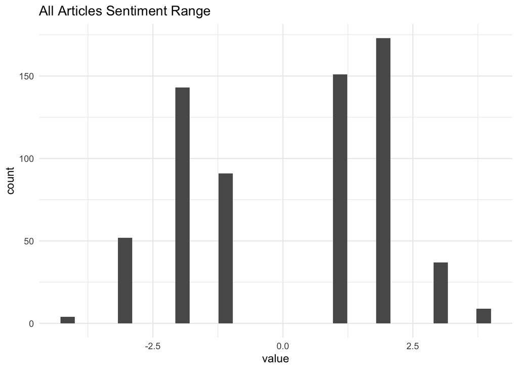

```r
ggplot(data = sentiment_affin_all,
       aes(x=value)
        )+
  geom_histogram()+
  ggtitle("All Articles Sentiment Range")+
  theme_minimal()
```

```r
article_words_nostop <- NE %>% distinct(word, .keep_all = TRUE) %>% anti_join(stop_words)
```

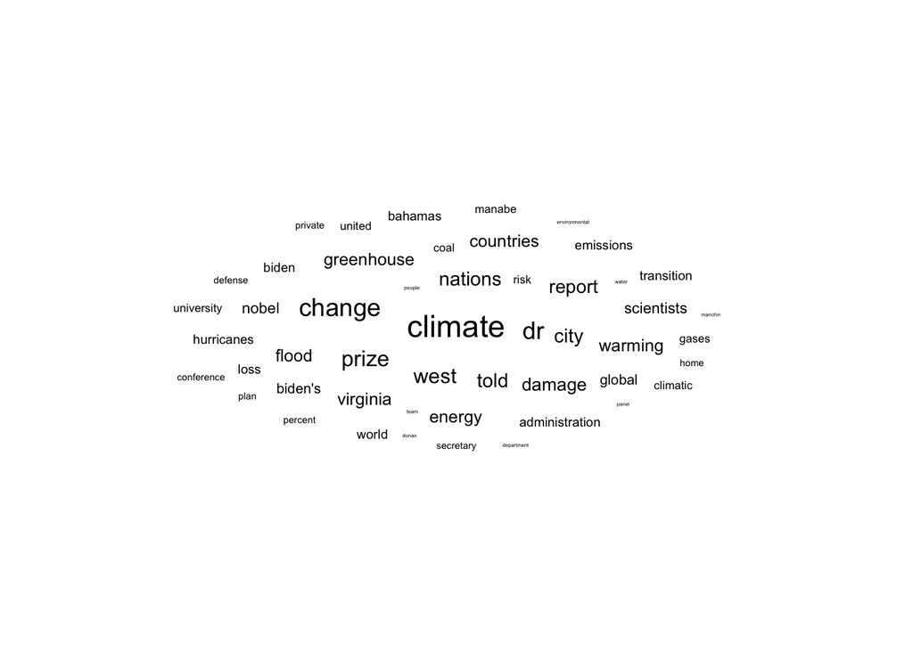

```r
set.seed(42)
ggplot(article_words_nostop[1:50,], aes(label = word, size = n)
       ) +
  geom_text_wordcloud() +
  theme_minimal()
```

#### Midwest : Chicago Daily Herald

To provide insight into individual word importance per article, a TF-IDF analysis is created. Each article is denoted by “c#” where “#” is the particular article number it represents. From this analysis, I am able to have the ability to see the term frequency (TF) relative to the Chicago Daily Herald as a whole, and the inverse document frequency (IDF) to understand how much that specific term is present in that particular article. Sorted from highest to lowest, the tf-idf represents the most critical word to that particular article in the scheme of the Chicago Daily Herald (Corpus).

```r
MW[order(MW$tf_idf, decreasing=T, na.last=F),]
```

```
## # A tibble: 1,736 × 7
##    chicagoDH word          n total     tf   idf tf_idf
##    <chr>     <chr>     <dbl> <dbl>  <dbl> <dbl>  <dbl>
##  1 c8        lakes        11   775 0.0142 2.30  0.0327
##  2 c1        birds        12   805 0.0149 1.61  0.0240
##  3 c4        deaths        9   272 0.0331 0.693 0.0229
##  4 c9        countries    10   564 0.0177 1.20  0.0213
##  5 c9        poor          7   564 0.0124 1.61  0.0200
##  6 c8        lake          9   775 0.0116 1.61  0.0187
##  7 c8        levels       12   775 0.0155 1.20  0.0186
##  8 c4        related       3   272 0.0110 1.61  0.0178
##  9 c4        cities        4   272 0.0147 1.20  0.0177
## 10 c5        children      9   834 0.0108 1.61  0.0174
## # … with 1,726 more rows
```

The highest tf-idf value from the output is the word “lakes” from the 8th analyzed article, or “c8”, which describes the relation between climate change the rising of the Great Lakes. This demonstrates that “lakes” is important on a local level to the article and also in terms of all the articles accumulated together. Similarly, the second highest tf-idf value is “birds” from the 1st analyzed article, or “c1,” which is an article describing the endangerment of bird habits from the impacts of climate change. Once again, the word “birds” is rightfully important most specifically to that article when compared to all the other articles as a whole. From this analysis, it is important to understand the frequency of words as they appear in individual articles and understand how that relates to the comparison between the variance in word frequencies across all documents.

/——————–

```r
# Table format of the categorized words
table(c_sentiment_nrc$sentiment)
```

```
##
##        anger anticipation      disgust         fear          joy     negative
##           59           73           38           71           58          125
##     positive      sadness     surprise        trust
##          199           58           42          133
```

/——————–

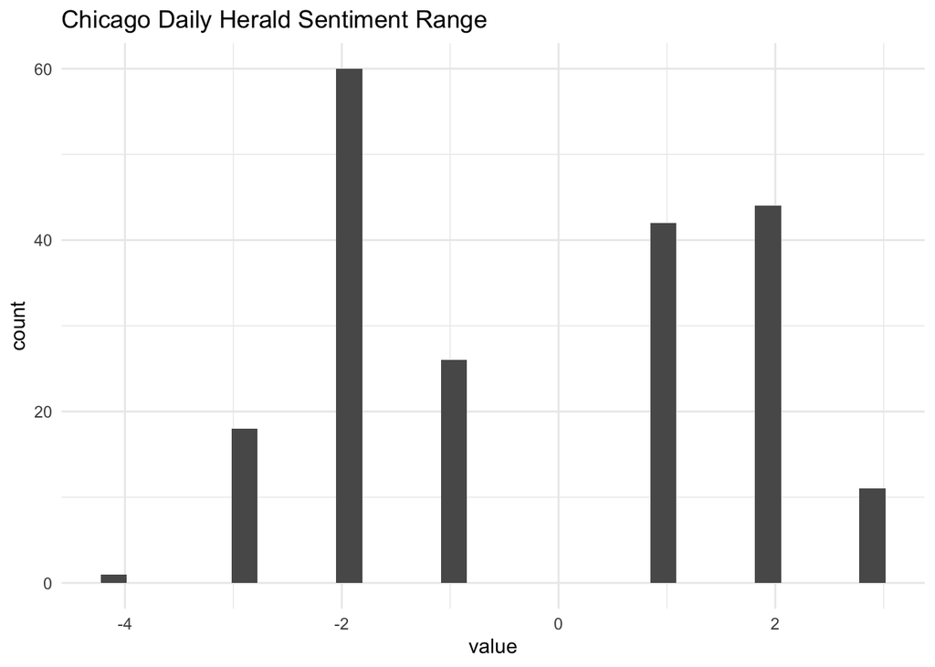

```r
# Plot the sentiment range w/o stop words
ggplot(data = c_sentiment_affin,
       aes(x=value)
        )+
  geom_histogram()+
  ggtitle("Chicago Daily Herald Sentiment Range")+
  theme_minimal()
```

In opposition to the “nrc” sentiment analysis, the “affin” sentiment analysis indicated a slighlty larger representation of negative words than positive words. The positive words are more evenly spread out among the various levels of positivity (0-3), whereas the negative words have a higher representation of the “-2” level of negativity. This can be related to the more moderate negative words that are referenced to climate change. Similarly, the positive words use more moderate references and are not overly positive comparatively. The reasoning for this can be reiterated from the section above where climate change, in terms of the Midwest, is relatively more of a neutral topic and therefore does not include either overly negative or overly positive words.

/——————–

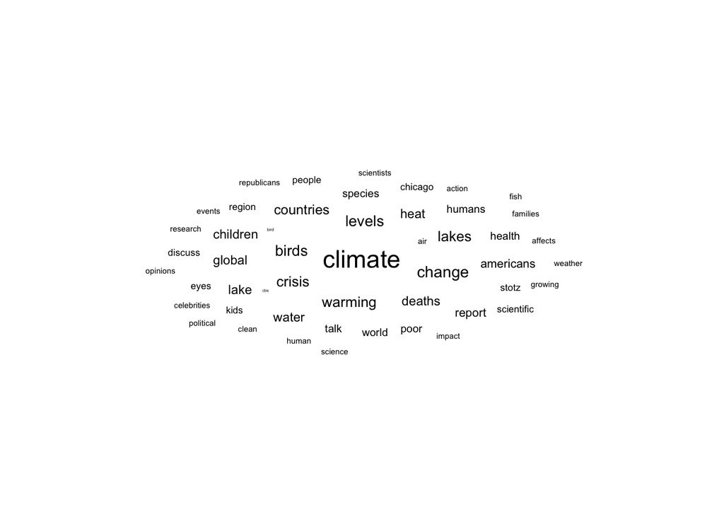

```r
# Make a word cloud w/o stop words
set.seed(42)
ggplot(MW[1:50,], aes(label = word, size = n)
       ) +
  geom_text_wordcloud() +
  theme_minimal()
```

#### West : LA Times

```r
W[order(W$tf_idf, decreasing = T, na.last = F),]
```

```
## # A tibble: 2,989 × 8
##     ...1 articles word               n total     tf   idf tf_idf
##    <dbl> <chr>    <chr>          <dbl> <dbl>  <dbl> <dbl>  <dbl>
##  1     9 LATimes4 lands             11  1068 0.0220 2.30  0.0506
##  2    14 LATimes4 wilkins           10  1068 0.0200 2.30  0.0460
##  3    30 LATimes6 investors          8   886 0.0186 2.30  0.0428
##  4     2 LATimes1 water             19   856 0.0458 0.916 0.0420
##  5     3 LATimes9 fire              19  1279 0.0316 1.20  0.0380
##  6    27 LATimes4 visitation         8  1068 0.0160 2.30  0.0368
##  7    38 LATimes5 defense            7   848 0.0151 2.30  0.0347
##  8    40 LATimes5 military           7   848 0.0151 2.30  0.0347
##  9    41 LATimes5 pentagon           7   848 0.0151 2.30  0.0347
## 10    89 LATimes7 reconciliation     5   651 0.0151 2.30  0.0347
## # … with 2,979 more rows
```

The tf_idf was calculated for the words in these articles, using tf_idf = tf*idf, which shows the general pattern of importance of certain words. To clarify, tf is the term frequency, and idf is the inverse document frequency. The importance and tf_idf are directly related, meaning the higher the value of the tf_idf, the more important the word is in the article. Therefore, the most important words that make sense in this situtaiton in the western region (Los Angeles Times) are words such as lands, investors, water, fire, visitation, defense, military, breaking, park, etc. When the tf_idf value were arranged in descending order, it was found that the highest tf_idf value was 0.05055576 for land, which totally makes sense. Climate change has had a significant effect on our land, so it makes sense that “land” is the most important word.

```r
newspaper_words_sentiment_nrc <- W %>%
  inner_join(get_sentiments("nrc"))
newspaper_words_sentiment_bing <- W %>%
  inner_join(get_sentiments("bing"))
table(newspaper_words_sentiment_bing$sentiment)
```

```
##
## negative positive
##      213      117
```

```r
table(newspaper_words_sentiment_nrc$sentiment)
```

```
##
##        anger anticipation      disgust         fear          joy     negative
##           94          127           52          138           66          198
##     positive      sadness     surprise        trust
##          273           81           49          159
```

For most of the articles, there is a significant gap between the number of positive and negative words, which is seen in the output of each of the bing sentiment analysis. Majority of the articles (7 out of the 10) include more negative words than positive words, 213 negative vs 117 positive in total, which is almost a 2:1 ration, and that makes sense based on the topic of the articles. Climate change is a very huge issue that takes place in the world, and the best way to get people to realize this is by raising the concern and making it clear that something must be done. On top of that, by comparing the results of the nrc sentiment analysis, it can be concluded that many of the words represent fear, trust, and anticipation, as they are the top 3 most counted for words.

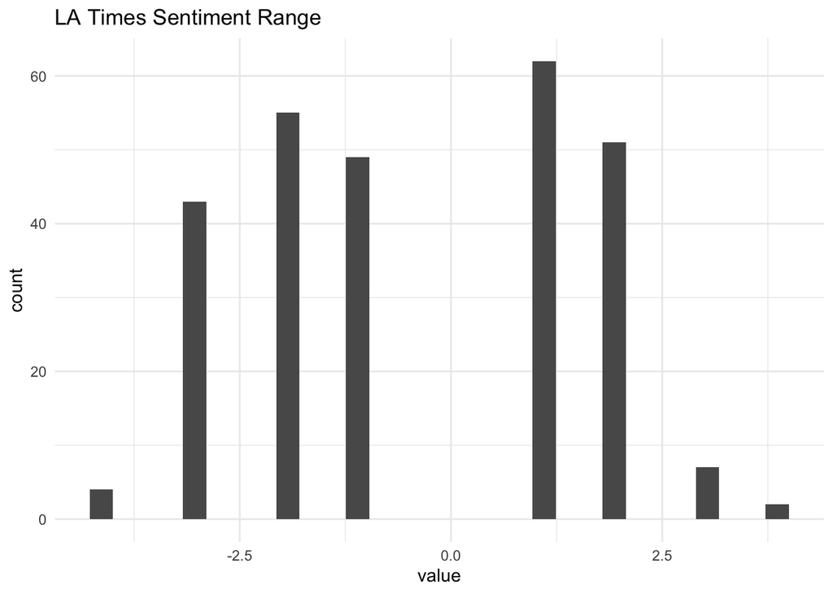

```r
newspaper_words_sentiment_affin <- W %>%
  inner_join(get_sentiments("afinn"))

ggplot(data = newspaper_words_sentiment_affin,
       aes(x=value)
        )+
  geom_histogram()+
  ggtitle("LA Times Sentiment Range")+
  theme_minimal()
```

It can be concluded that the histogram agrees with the nrc and bing sentiment analysis. This can be seen by the high negativity, higher word count below 0, and low positivity, lower word count above 0. Therefore, the words are more skewed to the left, indicating that the western region articles tend to be more negative.

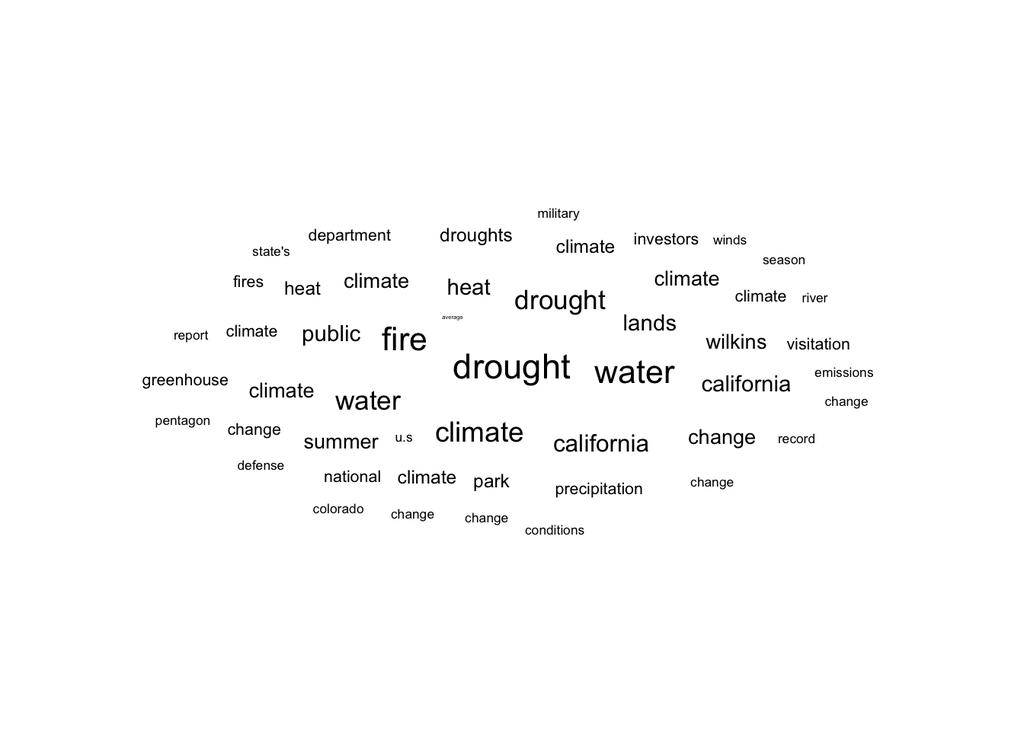

```r
#LA times word cloud
ggplot(W[1:50,], aes(label = word, size = n)
       ) +
  geom_text_wordcloud() +
  theme_minimal()
```

Based on the output of the word cloud that corresponds to the LA Times newspaper, which in this case is the corpus formed by combining the articles (documents), the most commonly said words are those that appear bolder, larger, an more often. Therefore, it seems that words such as “drought”, “water”,“fire”, and “climate” are mentioned quite often in Los Angeles Times Newspaper articles about climate change. This completely makes sense because in the western region, especially California, they often suffer from droughts, and wild fires. One of the most surprising words for me was “change” as I thought this word would possibly appear bolder and larger, because it would make sense that this word would be used often in articles about climate CHANGE.

#### South : Richmond Times Dispatch

I created an TF-IDF table from the left join of the word count and the total words. TF stands for Term Frequency, and IDF stands for Inverse Document Frequency. Term frequency is a metric to see how frequently a word shows up in the data when compared to the entire dataset. The inverse document frequency measures how much a word shows up in the article that it is originally from. The TF-IDF column is the values of the term frequency and the inverse document frequency multiplied together, and it represents the how crucial each word to its respective article in the scope of the entire dataset. I sorted My TF-IDF table in decreasing order so I could easily see which word was the most critical to my dataset. The word with the highest TF-IDF was migration, with a value of 0.06578. I believe this is because the article talks about the effect of people migration on climate change. Since the entire article has is concerned with migration, it makes sense that migration has the largest TF-IDF value.

```r
wordcloud <- function(x){
  set.seed(42)
  ggplot(x[1:50, ], aes(label = word, size = n)
       ) +
    geom_text_wordcloud() +
    theme_minimal()
}
afinnplot <- function(y){
  ggplot(data = y,
       aes(x = value)
        )+
  geom_histogram()+
  ggtitle("Sentiment Range")+
  theme_minimal()
}
S[order(S$tf_idf, decreasing = T, na.last = F),]
```

```
## # A tibble: 2,984 × 7
##    names      word               n total     tf   idf tf_idf
##    <chr>      <chr>          <dbl> <dbl>  <dbl> <dbl>  <dbl>
##  1 Article 6  migration         11   850 0.0286  2.30 0.0658
##  2 Article 10 building          18  1234 0.0267  2.30 0.0615
##  3 Article 8  woolf             12  1046 0.0233  2.30 0.0537
##  4 Article 1  li                 8   760 0.02    2.30 0.0461
##  5 Article 9  transportation    12   897 0.0253  1.61 0.0407
##  6 Article 5  salas              7   759 0.0175  2.30 0.0404
##  7 Article 3  canada             7   835 0.0171  2.30 0.0394
##  8 Article 10 rice              15  1234 0.0223  1.61 0.0358
##  9 Article 10 campus            10  1234 0.0148  2.30 0.0342
## 10 Article 10 students          10  1234 0.0148  2.30 0.0342
## # … with 2,974 more rows
```

The wordcloud that I made using the ten datasets combined was interesting to analyze. The first thing that I noticed was that one of my top words was “rice”. I was confused when I saw this, until I took examined the news article that the high frequency of “rice” had occurred in. The article was about a new climate change research center that had recently opened. The research center was named the Rice Rivers Center, hence why the word “rice” was one of the most prominent words in my word cloud. Another prominent word in my wordcloud was “building”, which also was from the article about the Rice Rivers climate change research center. I also noticed that the word “climate” was repeated multiple times, and was relatively large as well. This means that “climate” was repeated many times in several of the articles that were analyzed. This makes sense, as the articles were focused on climate change, in one way or another. One medium-sized word that I believed would have been larger or more repeated was “pollution”. I thought that news articles would be mentioning reducing pollution to slow down climate change or the amount of pollution and its effect on climate change. However, it seems like “pollution” was only prominent in a singular article - article 9.

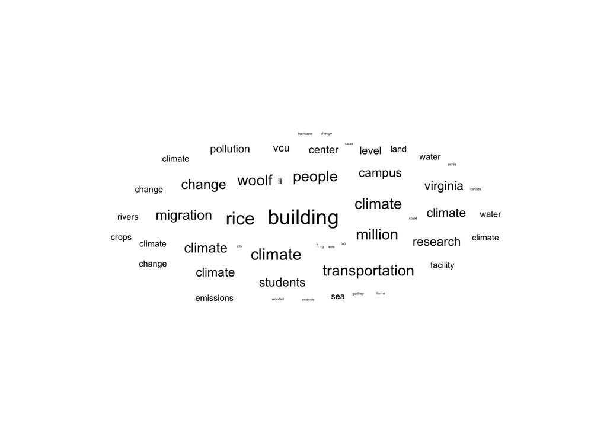

```r
totalwordcloud <- wordcloud(S)
totalwordcloud
```

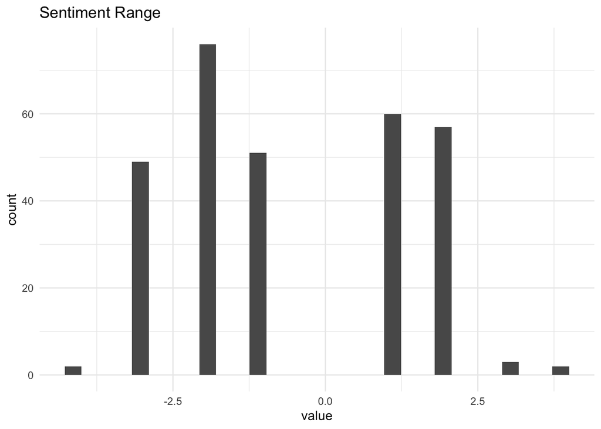

```r
S_afinn <- S %>%
  inner_join(get_sentiments("afinn"))
plot1 <- afinnplot(S_afinn)
plot1
```

I created a table from the sentimental values returned by checking the words in my datasets with the nrc table. The table that was returned was interesting to see, as it slightly contradicted my histogram at first glance. The category with the most amount of words is the positive category, which doesn’t align with what the histogram represented. However, when looking at the other sentiments, there were 61 words under the disgust category, 150 under the fear category, 221 under the negative category, and 97 under the sadness category. This aligns more with with the histogram from earlier, as the histogram showed a larger degree of negatively charged words. This is also reflected in the table, as words that fall under disgust or anger are more likely to be negatively charged.

```r
S_nrc <- S %>%
  inner_join(get_sentiments("nrc"))
table(S_nrc$sentiment)
```

```
##
##        anger anticipation      disgust         fear          joy     negative
##           88          122           61          150           65          221
##     positive      sadness     surprise        trust
##          303           97           69          184
```

#### Combined Analysis (by Region)

```r
# Top 25 words for each region
top_10_NE <- c("prize", "city", "capital", "private", "virginia", "investors", "west", "nobel", "bidens", "dr")
top_10_MW <- c("climate", "change", "birds", "levels", "crisis", "warming", "lakes", "countries", "death", "heat")
top_10_W <- c("lands", "wilkins", "investors", "water", "fire", "visitation", "defense", "military","pentagon", "reconciliation")
top_10_S <- c("migration", "building", "woolf", "li", "transportation", "salas", "canada", "rice", "campus", "students")

top_10 <- data.frame(top_10_NE, top_10_MW, top_10_W, top_10_S)
top_10
```

```
##    top_10_NE top_10_MW       top_10_W       top_10_S
## 1      prize   climate          lands      migration
## 2       city    change        wilkins       building
## 3    capital     birds      investors          woolf
## 4    private    levels          water             li
## 5   virginia    crisis           fire transportation
## 6  investors   warming     visitation          salas
## 7       west     lakes        defense         canada
## 8      nobel countries       military           rice
## 9     bidens     death       pentagon         campus
## 10        dr      heat reconciliation       students
```

After combining the top 10 words from each region, there is an apparent difference between the 4 regions. Starting from the Northeast region, there is an economic focus that can be characterized by the inclusion of the words “investors”, “capital” and “prize.” This trend can most likely be attributed to the main newspaper source for the region being the New York Times. New York City is an economically motivated city that will tend to focus specifcally on those negative impacts of climate change. Furthermore, the top words from the Northeast region were rather neutral in terms of positive and negative connotation. The Midwest region was similar in comparison to the Northeast region. There was a geographic focus that can be attributed to the Great Lakes and the impact that region will feel from climate change. This geographic focus can be highlighted by the top words “birds”, “lakes,” “countries.” Connotatively, the words were also rather neutral and didn’t tend too much towards overly positive or overly negative terms. In addition, the West region had a similar geographic focus. The forest fires and droughts experienced across the West region are key contributors to the top words featured across the multiple articles. These can be characterized by the words “lands,” “water,” and “fire.” On the other hand, there was a military element that had an overarching negative connotation across many of the terms. The Los Angeles Times is based from a large US city, which can be a reason for the particular focus on national defense. Lastly, the South region had a larger variance between the themes between the top terms. Based on the general focus of the newspaper, there was an emphasis on infrastructure and the role that the migration of people into the suburbs surrounding cities contributes to climate change in the South. From this, it explains the general negative connoation of the terms featured from this region.

*Regional Analysis Importance*

Concluding the regional analysis across the United States, it is crucial that there is an understanding of the factors important to each region and how those factors influence the press. Specifically in relation to climate change, the impacts are different all across the country, so it is important that there is a knowledge about the context from each section data. Regardless of the potentially inaccurate generalization from the sentiment analysis, it is useful to grasp a general understanding prior to full analysis.

Recommendations:

1. Perform sentiment analysis on each region
2. Understand the data in terms of the context of each document
3. Make conclusions based on that understanding